# Problem set 3: Nests in a patchy landscape

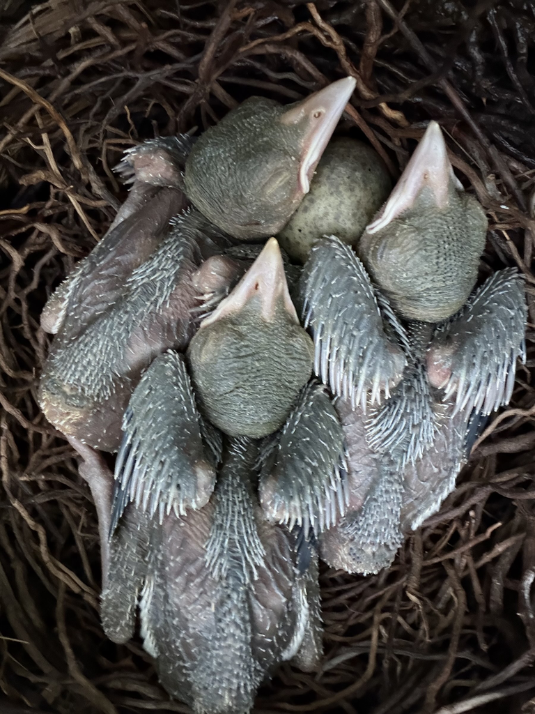

My grad student Tara’s research asks when nest concealment protects birds from predation and why that relationship may change across the breeding season. At the Smithsonian Conservation Biology Institute in Front Royal, Virginia, Tara and her field team monitor nests in shrub-dominated habitat patches. They record nest locations with GPS and survey potential predators from a fixed-radius point count in each patch. These spatial data provide the setting for later tests of how concealment, parental activity, vegetation, and predator communities interact.

In this problem set, you will work with spatial data based on that study: nest locations, habitat patch boundaries, and one point count location per patch. Before these data can support an ecological analysis, the files must be read, constructed, and placed in a coordinate reference system appropriate for each task. You will then describe the spatial extent of the nests, evaluate the locations of the point counts, and map the study area. The ten questions draw from every lesson in Module 3.

## Grading

**Total points available: 10**

The points allotted for each question are provided in highlighted red bold text (e.g., [1.0]) within the question itself. When applicable, total points for a question may represent the sum of individually graded components, which are provided in red text (e.g., [1.0]).

**Points may be deducted from each question’s original point value:**

- [50% per unapproved function] Use only functions that are listed in “Functions that you may use in this assignment”. Repeated uses of the same unapproved function will not result in additional deductions.
- [50%] Do not include any assignments other than those specified in a question.
- [25%] Do not use numeric column indexing for extracting data from data frames or named lists (e.g., `my_df[[1]]`).
- [10%] Ensure that the class of your response is consistent with the wording of the question (e.g., if you are asked to return a “value” or “vector”, ensure that the resultant object is not a data frame).

*Note: The maximum deduction is the total points value for a given question.*

**An additional 10% of a question’s original point value will be awarded when the response follows all applicable rules in the [Course style guide](https://evansbrians.github.io/gis_2026/resources/course_style_guide/). Style extra credit is assessed separately for each question; a response with one or more style violations receives no style extra credit for that question.**

Click the blue button below to view the functions that you may use in completing this problem set. Make sure that you know what each function does (use `?[function name]` if you do not). Do not use any functions outside of this list!

**Important!** Primitive functions and functions in the *base* package are loaded by default when you start an R session. Functions in *dplyr*, *ggplot2*, *readr*, *tibble*, and *tidyr* are loaded with `library(tidyverse)`. Although the *magrittr* package is not a part of the core tidyverse, the `%>%` function is imported by the *dplyr* (core tidyverse) library. The functions `st_area()` and `set_units()` return values with units attached, so the *units* package is loaded alongside *sf*.

In answering the questions for this assignment, you may **only** use the following R functions in your submitted R script (but you may use additional functions to explore the data):

- `.Primitive, ()`
- `.Primitive, <-`
- `.Primitive, =`
- `.Primitive, ==`
- `.Primitive, +`
- `.Primitive, -`
- `.Primitive, $`
- `.Primitive, [`
- `.Primitive, ::`
- `.Primitive, c`
- `.Primitive, min`
- `base::library`
- `base::source`
- `dplyr::arrange`
- `dplyr::count`
- `dplyr::desc`
- `dplyr::filter`
- `dplyr::join_by`
- `dplyr::left_join`
- `dplyr::mutate`
- `dplyr::n`
- `dplyr::select`
- `dplyr::summarize`
- `magrittr::%>%`
- `readr::read_csv`
- `sf::st_area`
- `sf::st_as_sf`
- `sf::st_buffer`
- `sf::st_centroid`
- `sf::st_crs`
- `sf::st_distance`
- `sf::st_point`
- `sf::st_read`
- `sf::st_sf`
- `sf::st_sfc`
- `sf::st_transform`
- `source_script_module_3.R, count_vertices`
- `tibble::as_tibble`
- `tmap::tm_basemap`
- `tmap::tm_borders`
- `tmap::tm_dots`
- `tmap::tm_legend`
- `tmap::tm_polygons`
- `tmap::tm_scale_continuous`
- `tmap::tm_shape`
- `tmap::tm_title`
- `tmap::tmap_mode`
- `units::set_units`

## About the data

This problem set uses `patches.geojson`, the Esri shapefile `nest_locations.shp`, and `point_count_locations.csv`, which describe the same study area. Place the spatial vector files in `data/raw/shapefiles` and the CSV file in `data/raw`.

**`patches.geojson`** is a polygon shapefile of habitat patches, recorded in EPSG 32617. The file contains the following fields:

- `patch_id` (character): A code that identifies the patch.
- `patch_label` (character): The name of the patch.
- `geometry` (polygon): The boundary of the patch.

**`nest_locations.shp`** is a point shapefile of nests, recorded in EPSG 4326. Its field names are abbreviated. The file contains the following fields:

- `nest_id` (character): A code that identifies the nest.
- `patch_d` (character): The patch in which the nest was recorded, matching `patch_id` in `patches.geojson`.
- `dscvry_` (date): The date the nest was found. Some nests have no recorded date.
- `geometry` (point): The location of the nest.

**`point_count_locations.csv`** is a tabular dataset of the point count locations, one per patch. The coordinates were recorded with a handheld GPS unit set to EPSG 4326. The file contains the following variables:

- `point_name` (character): The name of the point count location.
- `patch_id` (character): The patch associated with a point count location.
- `latitude` (numeric, double): The latitude of the point count location, in decimal degrees.
- `longitude` (numeric, double): The longitude of the point count location, in decimal degrees.

## Setup

Remember that it is best practice to start with a clean RStudio session (i.e., close any script files, remove names from your global environment, and clear your history).

1. [0.25] Before opening the script, rename `problem_set_3.R` as “problem_set_3_[last name]_[first name].R” using snake case. For example, Tara would name her file `problem_set_3_snedgen_tara.R`.

*Note: You will submit this script file as your assignment.*

2. [0.50] Prepare your session:

- [0.20] Attach *sf*, *tmap*, and the tidyverse metapackage to your current R session.
- [0.20] Set the *tmap* mode such that all *tmap* code will generate interactive maps.
- [0.10] Load `source_script_module_3.R`.

*Hint: Please see **3.2 Introduction to spatial vector data**.*

## Reading spatial vector data

3. [0.50] Read the spatial vector files. Use a relative file path for each.

- [0.25] Read `patches.geojson` and globally assign it to the name `patches`. Allow the file metadata to print.
- [0.25] Read `nest_locations.shp` and globally assign it to the name `nests`. In doing so, suppress the printing of the file metadata.

*Hint: Please see **3.2 Introduction to spatial vector data**.*

## From coordinate fields to features

4. [1.0] The point count locations are stored in a CSV file with longitude and latitude fields rather than a geometry. In a single piped statement:

- [0.20] Read `point_count_locations.csv` with a relative file path.
- [0.50] Convert the result to a point simple features object, supplying the coordinate reference system in which the coordinates were recorded.
- [0.25] Convert the CRS to the same CRS as `patches`
- [0.05] Globally assign the result to the name `point_counts`.

*Hint: The order in which you name the coordinate columns matters! Please see **3.2 Introduction to spatial vector data** and **3.4 The coordinate reference system: Why it matters and how to use it**.*

## The coordinate reference system

5. [1.25] Prepare the objects for mapping.

- [0.30] In separate code blocks, return the EPSG code of `patches`, `nests`, and `point_counts`, each as a single integer value.
- [0.30] Using a single clode block, return an integer vector containing the number of vertices in `patches`, `nests`, and `point_counts`, in that order.
- [0.65] Using the decision rules in **3.2 Introduction to spatial vector data**, transform the object(s) such that patches, nests, and point counts share a CRS. Globally assign the transformed object(s), adding the suffix `_transformed` to the previously assigned name(s).

*Hint: Please see **3.2 Introduction to spatial vector data** and **3.4 The coordinate reference system: Why it matters and how to use it**.*

## The size of each habitat patch

6. [1.25] Tara will use patch area to help decide how many trail cameras each habitat patch can accommodate.

Using the `patches` shapefile, return a tibble data frame containing `patch_id` and `patch_area`, with area reported in hectares. Arrange the patches from largest to smallest. Do not assign the result to a name or overwrite an existing global assignment.

*Hint: Please see **3.4 The coordinate reference system: Why it matters and how to use it** and **3.6 Geometric operations with sf**.*

## Mapping with tmap

7. [1.25] Tara and her field team have been finding nests throughout the spring and summer. Create an interactive field map that Tara and her team can use to relocate monitored nests. Display the habitat patches and nest locations over the Esri World Imagery basemap. Make the nest locations clearly visible and include an informative map title and layer names.

*Hint: Please see **3.5 Introduction to tmap**.*

## Spatial buffers

8. [1.0] Tara’s current point count locations are outside the habitat patches. She is thinking of adding a point count location at the geometric center of the patch named “Firehouse”. Within a single code block:

- [0.25] Subset `point_counts` and `patches` to the patch named “Firehouse”.
- [0.25] Calculate the centroid of the Firehouse patch
- [0.25] Create an interactive map that displays the `points_counts`, `patches`, and centroid layers (each subset to Firehouse)
- [0.25] Draw a 100 m buffer around the original point count location and the Firehouse centroid.

*Hint: Please see **2.1 Subsetting and extraction**, **3.6 Geometric operations with sf** and **3.5 Introduction to tmap**.*

## Assigning a nest to a habitat patch

9. [1.50] Tara records a nest at longitude -78.1685 and latitude 38.8940, outside the mapped habitat patches. The coordinates were recorded in EPSG 4326. She needs to determine which patch is closest to the nest.

- [0.75] Construct a one-feature point simple features object from the coordinates, supplying the CRS in which they were recorded. Transform the object to the existing projected CRS and globally assign the result to the name `new_nest`.
- [0.75] Calculate the distance from `new_nest` to every habitat patch. Return a one-row tibble data frame containing `patch_id`, `patch_label`, and `distance_to_nest` for the closest patch, with distance reported in meters. Do not assign the result to a name or overwrite an existing binding.

*Hint: Please see **3.3 Constructing and converting simple features**, **3.4 The coordinate reference system: Why it matters and how to use it**, and **3.6 Geometric operations with sf**.*

## Counting nests

10. [1.50] Tara wants a visualization of the number of nests associated with each patch. Please create an interactive map that uses fill color to display the number of nests assigned to each patch.

*Hint: Please see **2.3 Grouped operations and summarize**, **2.6 Tidy data**, and **3.5 Introduction to tmap**.*